# Practica1

2022-08-29

#Ejericio 1:

Cargamos los datos Debernardi.csv

```r
setwd("~/Documents/FCEyN/Estadistica/Datos")
debD = read.csv("Debernardi.csv")
```

- Construir una tabla con los valores observados para la variable diagnosis y su frecuencia relativa. luego hacer uns grafico de barras con el.

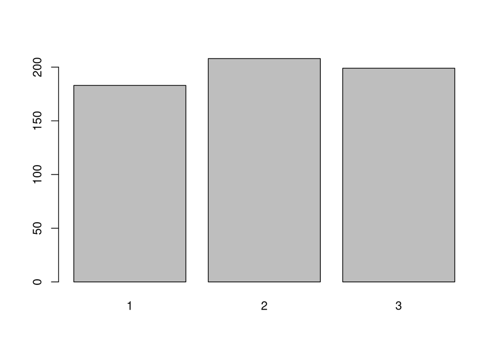

```r
diagnosis = table(debD$diagnosis)
barplot(diagnosis)
```

#Ejericio 2:

- Estimar la probabilidad de ser mujer sabiendo que sobrevivió y comparar con la estimación de ser mujer a bordo del Titanic.

```r
setwd("~/Documents/FCEyN/Estadistica/Datos")
titanic = read.csv("datos_titanic.csv")
Psm = titanic$Sex[titanic$Survived == 1]

length(Psm[Psm == "female"]) / length(Psm)
```

```
## [1] 0.6812865
```

- Hacer una tabla de contingencia entre las variables categóricas Survived y Pclass, luego hacer un grafico de barras.

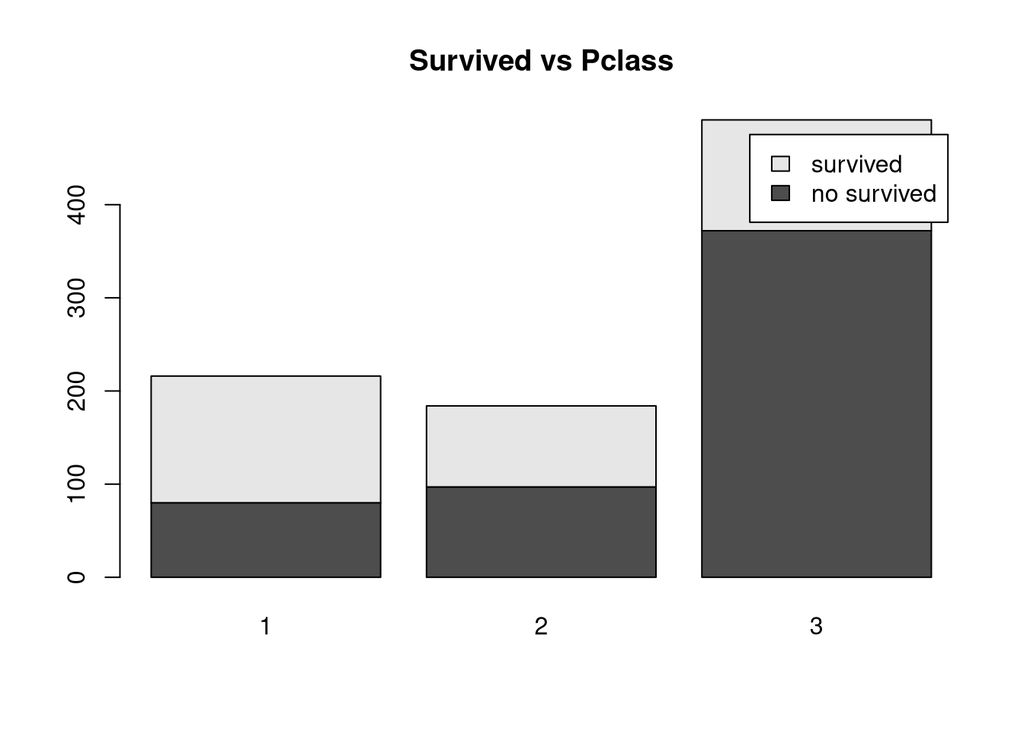

```r
t_contringencia = table(titanic$Survived, titanic$Pclass)

barplot(t_contringencia, main="Survived vs Pclass",legend = c("no survived","survived"))
```

Ejercicio 3:

- Comparar los dos conjuntos de datos mediante histogramas y boxplots, graficando los boxplots en paralelo

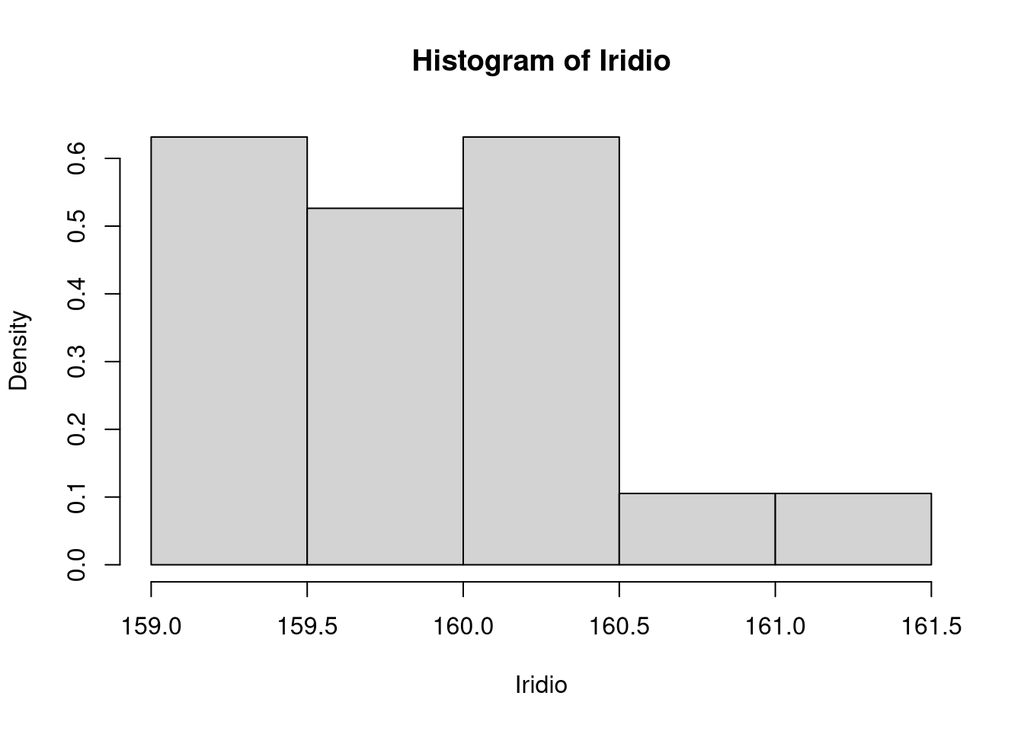

```r
setwd("~/Documents/FCEyN/Estadistica/Datos")
library("ggplot2")
iridio = read.table("iridio.txt",header = TRUE)
rodio = read.table("rodio.txt", header = TRUE)
iridio = iridio$iridio
rodio = rodio$rodio

hist(iridio, main = "Histogram of Iridio", freq = FALSE, xlab = "Iridio")
```

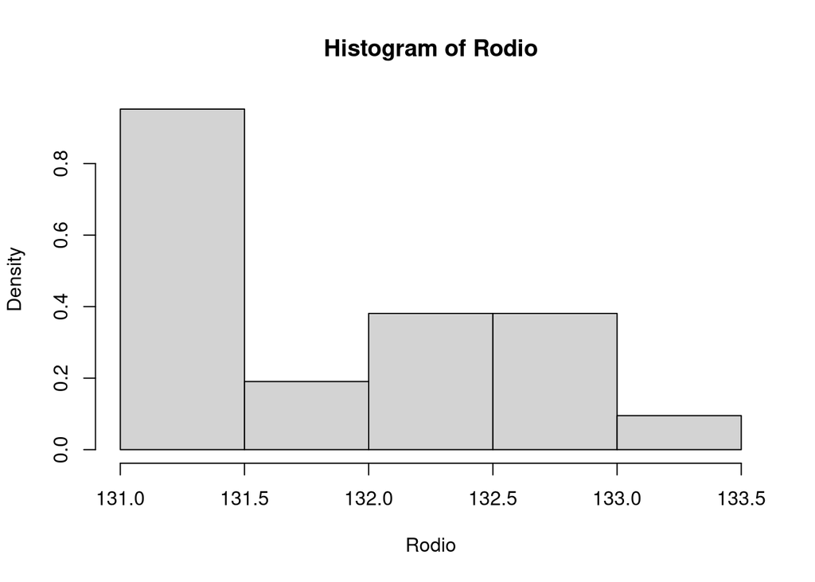

```r
hist(rodio, main = "Histogram of Rodio", freq = FALSE, xlab = "Rodio")
```

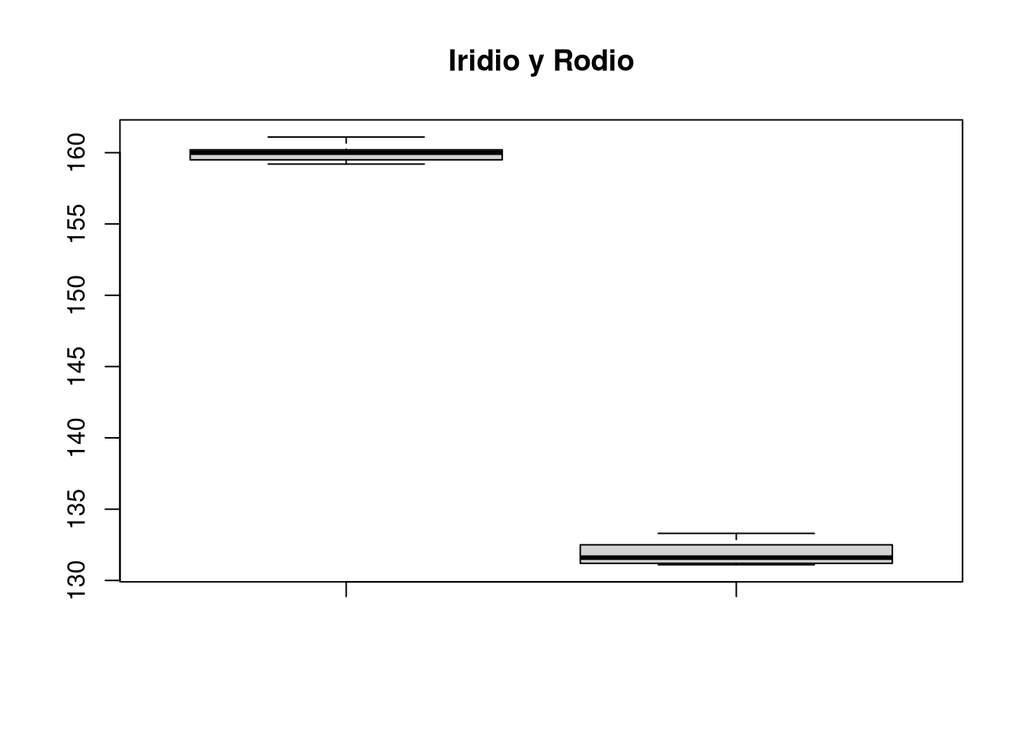

```r
boxplot(iridio, rodio, main= "Iridio y Rodio")
```

- Hallar las medias, las medianas y las medias podadas al 10 % y 20 % muestrales. Comparar.

```r
t = matrix(nrow = 2,ncol = 4, byrow = TRUE)

t[1,1] = mean(iridio)
t[2,1] = mean(rodio)
t[1,2] = median(iridio)
t[2,2] = median(rodio)
t[1,3] = mean(iridio, trim = 0.1)
t[2,3] = mean(rodio, trim = 0.1)
t[1,4] = mean(iridio, trim = 0.2)
t[2,4] = mean(rodio, trim = 0.2)

t = as.table(t)
rownames(t) = c("Iridio","Rodio")
colnames(t) = c("Media","Mediana","Media01Podada","Media02Podada")
t
```

```
##           Media  Mediana Media01Podada Media02Podada
## Iridio 159.9158 160.0000      159.8882      159.8692
## Rodio  131.8762 131.6000      131.8176      131.7692
```

- Hallar los desvı́os estándares, las distancias intercuartiles y las MAD muestrales como medidas de dispersión

```r
m = matrix(nrow = 2,ncol=3)

m[1,1] = sd(iridio)
m[2,1] = sd(rodio)
m[1,2] = IQR(iridio)
m[2,2] = IQR(rodio)
m[1,3] = mad(iridio)
m[2,3] = mad(rodio)

m = as.table(m)
rownames(m) = c("Iridio","Rodio")
colnames(m) = c("desviación estándar","Distancia IQ","MAD")
m
```

```
##        desviación estándar Distancia IQ       MAD
## Iridio           0.4901963    0.7000000 0.5930400
## Rodio            0.7509359    1.3000000 0.7413000
```

- Hallar los cuantiles 0,90, 0,75, 0,50, 0,25 y 0,10

```r
u = matrix(nrow = 2,ncol = 5)
u[1,1] = quantile(iridio,0.9)
u[2,1] = quantile(rodio,0.9)
u[1,2] = quantile(iridio,0.75)
u[2,2] = quantile(rodio,0.75)
u[1,3] = quantile(iridio,0.5)
u[2,3] = quantile(rodio,0.5)
u[1,4] = quantile(iridio,0.25)
u[2,4] = quantile(rodio,0.25)
u[1,5] = quantile(iridio,0.1)
u[2,5] = quantile(rodio,0.1)

u = as.table(u)
rownames(u) = c("Iridio","Rodio")
colnames(u) = c("0.9","0.75","0.50","0.25","0.1")
u
```

```
##           0.9   0.75   0.50   0.25    0.1
## Iridio 160.44 160.20 160.00 159.50 159.46
## Rodio  133.00 132.50 131.60 131.20 131.10
```

# Ejericio 4:

- Realizar un histograma para las calorı́as de cada tipo de salchichas. ¿Observa grupos en algún gráfico? ¿Cuántos grupos observa? ¿Observa algún candidato a dato atı́pico? ¿Alguno de los histogramas tiene una caracterı́stica particular? .

```r
#Cargamos los datos
setwd("~/Documents/FCEyN/Estadistica/Datos")
salA = read.table("salchichas_A.txt",header = TRUE)
salB = read.table("salchichas_B.txt",header = TRUE)
salC = read.table("salchichas_C.txt",header = TRUE)
```

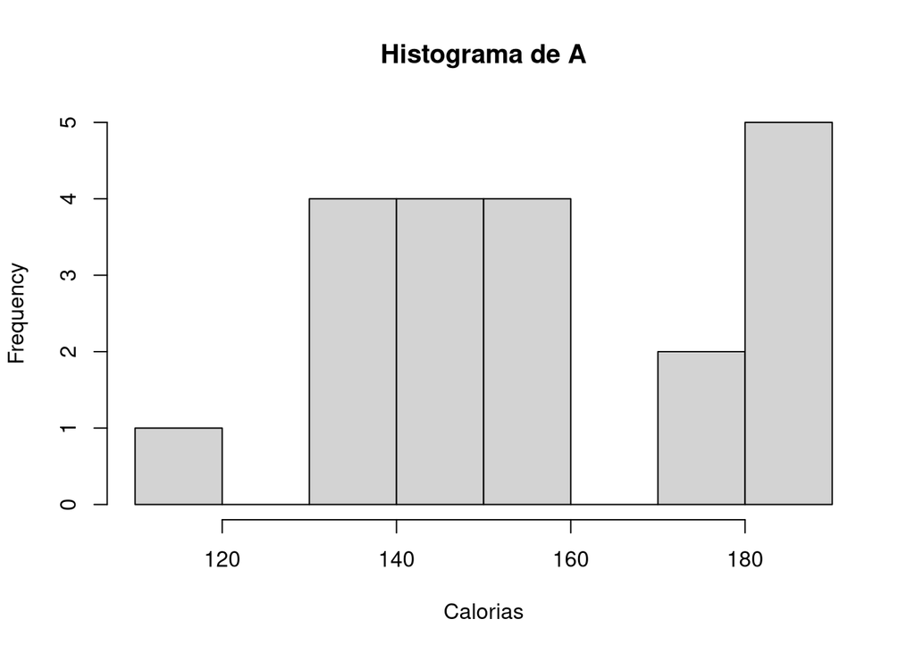

```r
hist(salA$CALORIAS.A,main = "Histograma de A",xlab = "Calorias")
```

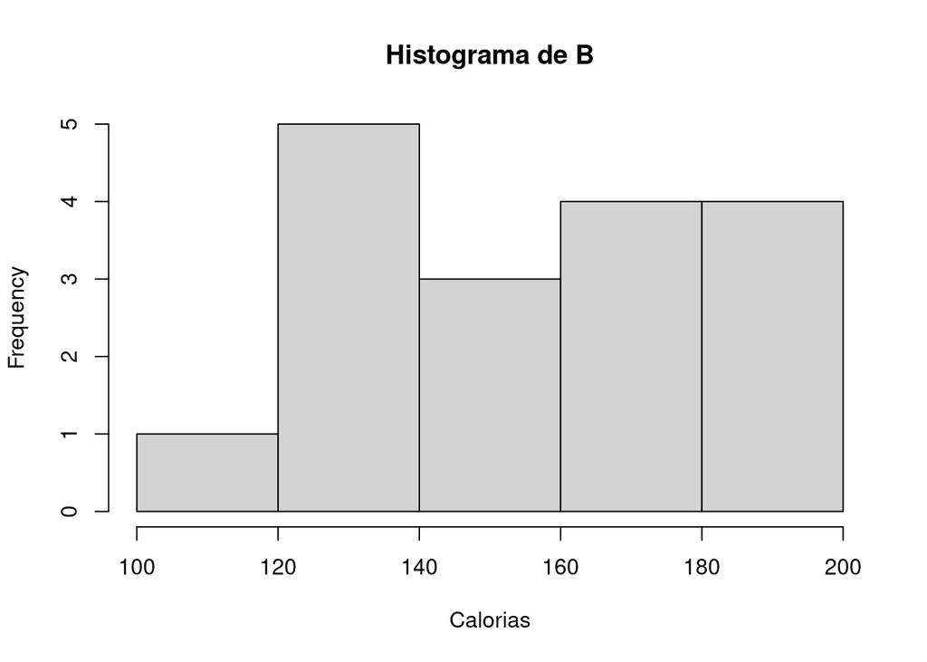

```r
hist(salB$CALORIAS.B,main = "Histograma de B",xlab = "Calorias")
```

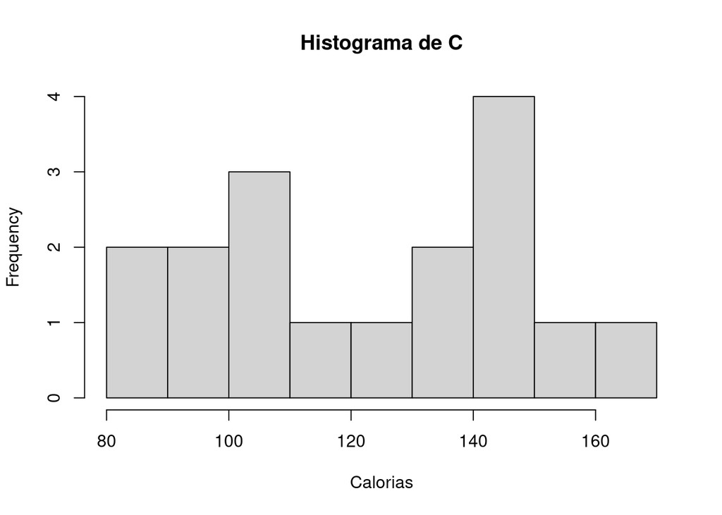

```r
hist(salC$CALORIAS.C,main = "Histograma de C",xlab = "Calorias")
```

* Realizar los boxplots paralelos para las calorı́as.

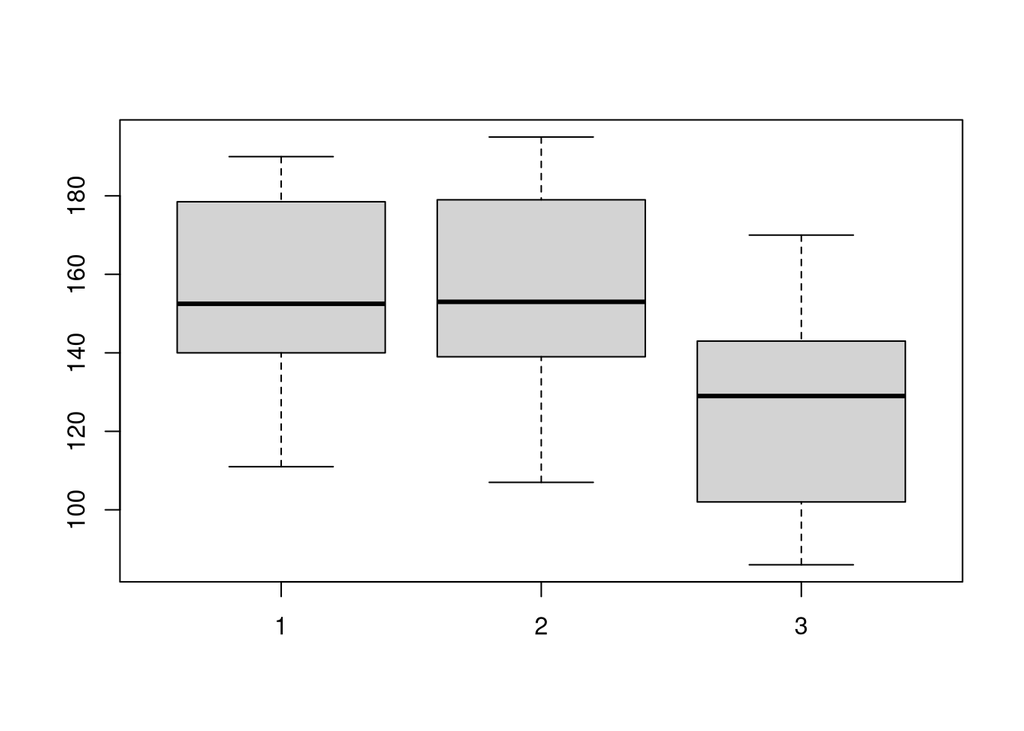

```r
boxplot(salA$CALORIAS.A,salB$CALORIAS.B,salC$CALORIAS.C)
```

- Repetimos con la cantidad de sodio.

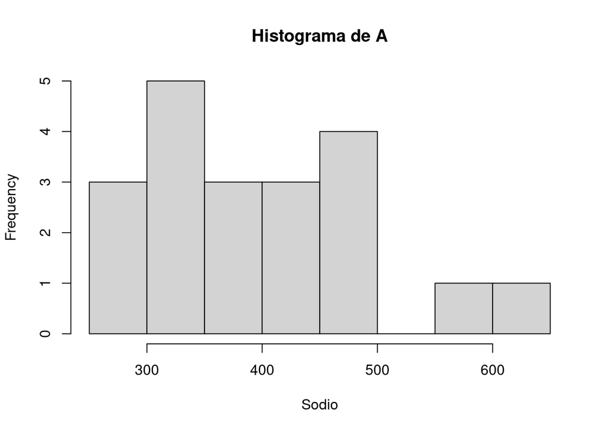

```r
hist(salA$SODIO.A,main = "Histograma de A",xlab = "Sodio")
```

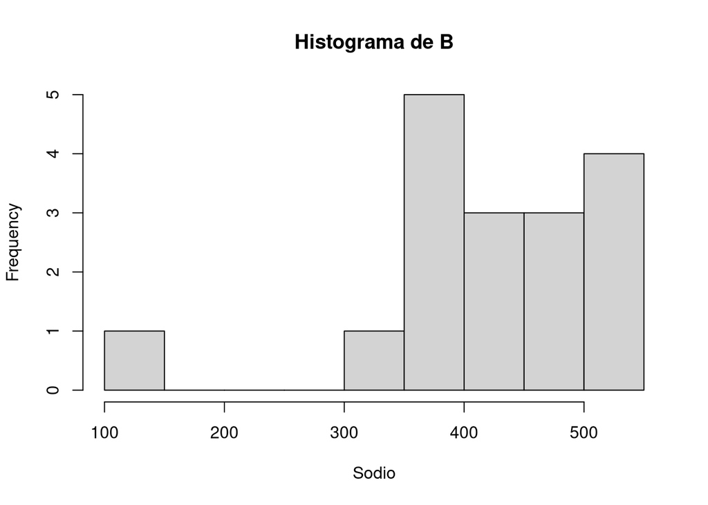

```r
hist(salB$SODIO.B,main = "Histograma de B",xlab = "Sodio")
```

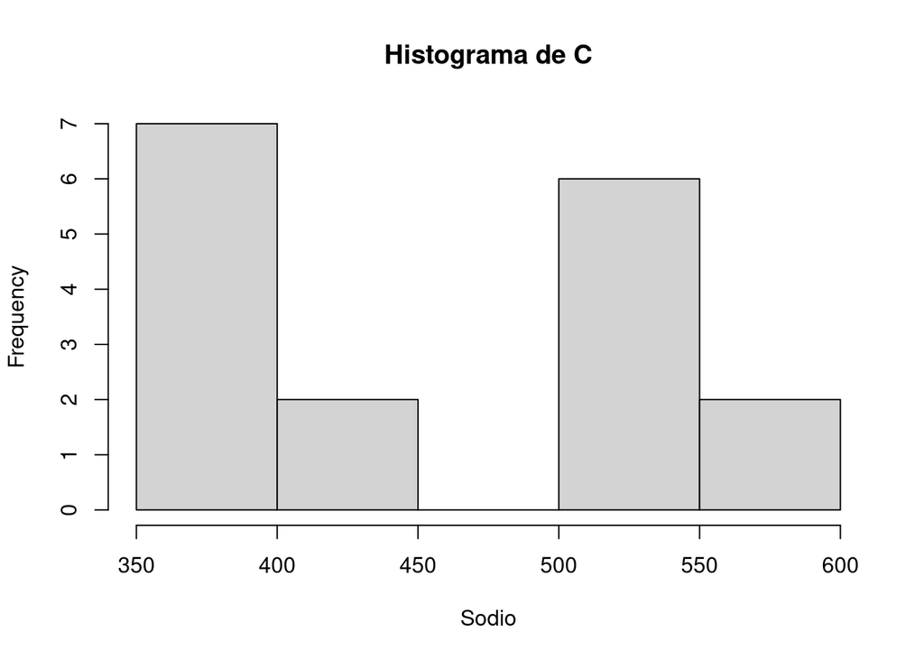

```r
hist(salC$SODIO.C,main = "Histograma de C",xlab = "Sodio")
```

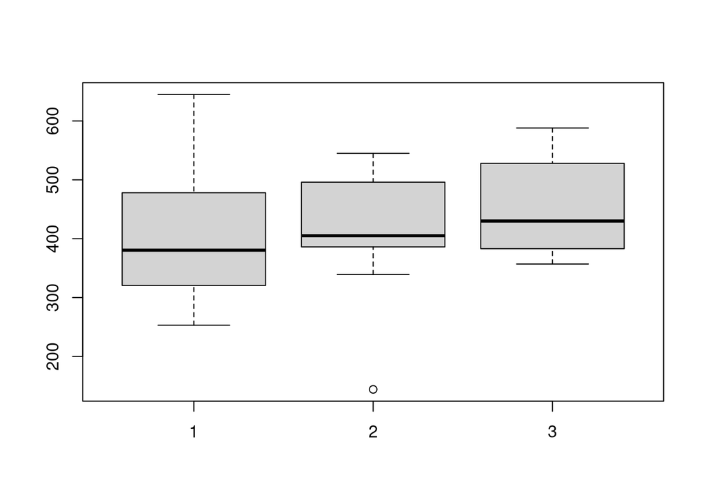

```r
boxplot(salA$SODIO.A,salB$SODIO.B,salC$SODIO.C)
```

# Ejericio 5:

- Cargamos los datos.

```r
setwd("~/Documents/FCEyN/Estadistica/Datos")
est = read.table("estudiantes.txt", header = TRUE)
```

- Estudiar si la distribución de los conjuntos de datos para ambos grupos es normal.

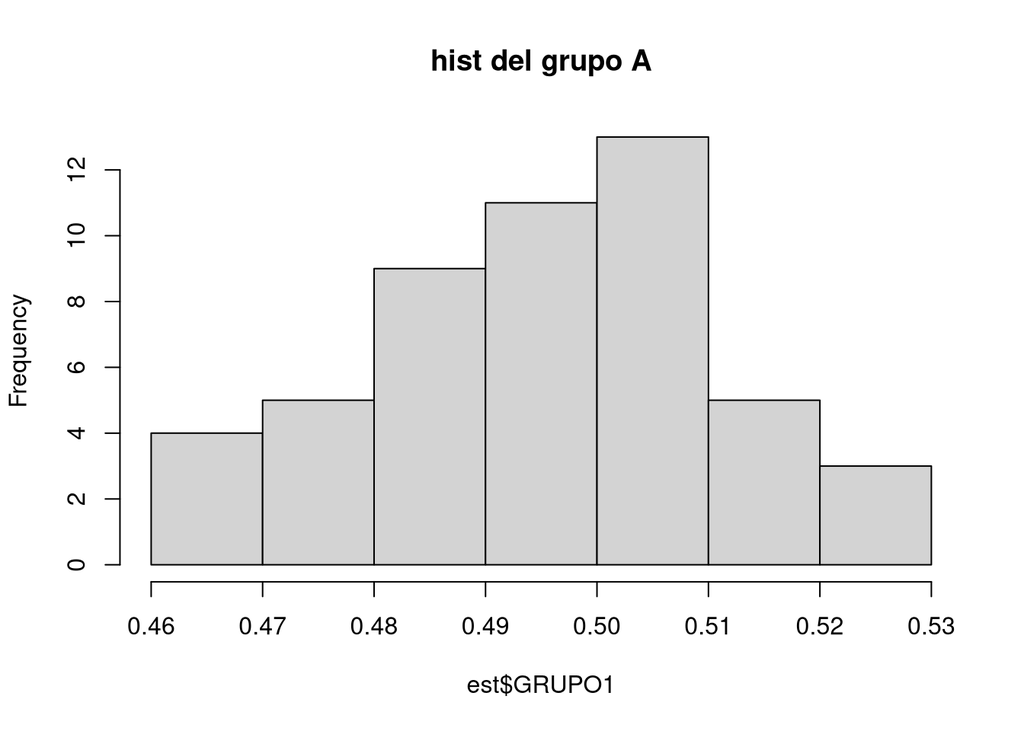

```r
hist(est$GRUPO1, main = "hist del grupo A")
```

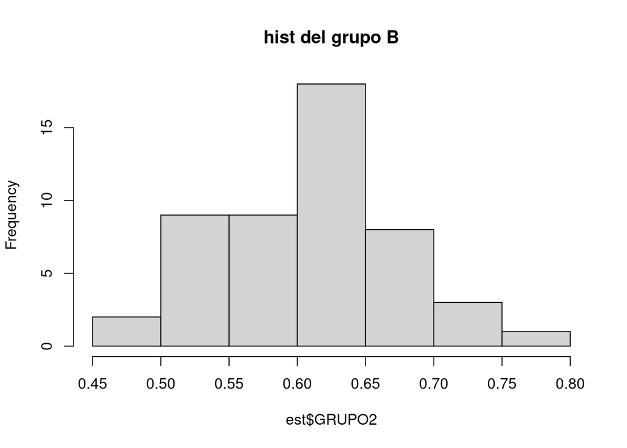

```r
hist(est$GRUPO2, main = "hist del grupo B")
```

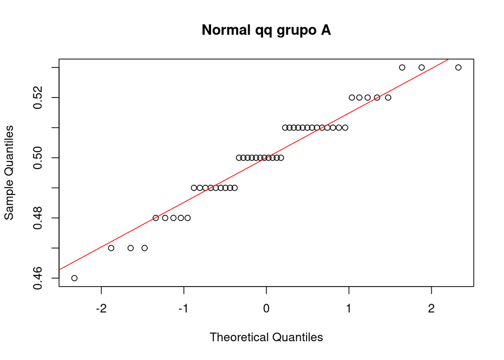

```r
qqnorm(est$GRUPO1, main = "Normal qq grupo A")
qqline(est$GRUPO1,col="red")
```

[figure not shown]

```r
qqnorm(est$GRUPO2, main = "Normal qq grupo A")
qqline(est$GRUPO2,col="red")
```

* ¿Le parece a partir de estos datos que ambos grupos están midiendo lo mismo?

```r
centralidad = matrix(nrow = 2,ncol = 4)
centralidad[1,1] = mean(est$GRUPO1)
centralidad[2,1] = mean(est$GRUPO2)
centralidad[1,2] = median(est$GRUPO1)
centralidad[2,2] = median(est$GRUPO2)
centralidad[1,3] = mean(est$GRUPO1,trim = 0.2)
centralidad[2,3] = mean(est$GRUPO2,trim = 0.2)
centralidad[1,4] = mad(est$GRUPO1)
centralidad[2,4] = mad(est$GRUPO2)
centralidad = as.table(centralidad)
rownames(centralidad) = c("Grupo 1","Grupo 2")
colnames(centralidad) = c("media", "mediana", "-0.2 podada", "MAD")
centralidad
```

```
##            media  mediana -0.2 podada      MAD
## Grupo 1 0.500000 0.500000    0.501000 0.014826
## Grupo 2 0.613600 0.610000    0.612000 0.066717
```

Algo parecido se puede hacer con medidas de dispersion pero se graficamente.

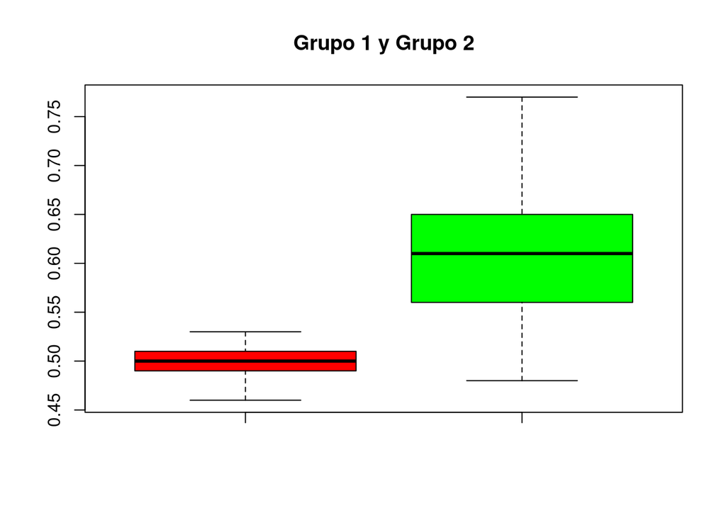

```r
boxplot(est$GRUPO1,est$GRUPO2,main= "Grupo 1 y Grupo 2", col = c("red","green"))
```

Parecen estar midiendo cosas distintas, ya que las medidas de dispersion difieren por mucho, y algo parecido pasa con las medidas de centralidad.

# EJericio 6:

```r
#cargamos los datos
setwd("~/Documents/FCEyN/Estadistica/Datos")
nubes = read.table("nubes.txt",header=TRUE)
```

- Realizar boxplots paralelos. ¿Le parece que el método produce algún efecto? > Parece haber mas outliyers favorables.
- Realizar boxplots paralelos habiendo transformado las variables con el logaritmo natural. Observar cómo se modificaron los datos atı́picos respecto del ı́tem a). > Los outliyers parecen haberse “normalizados”

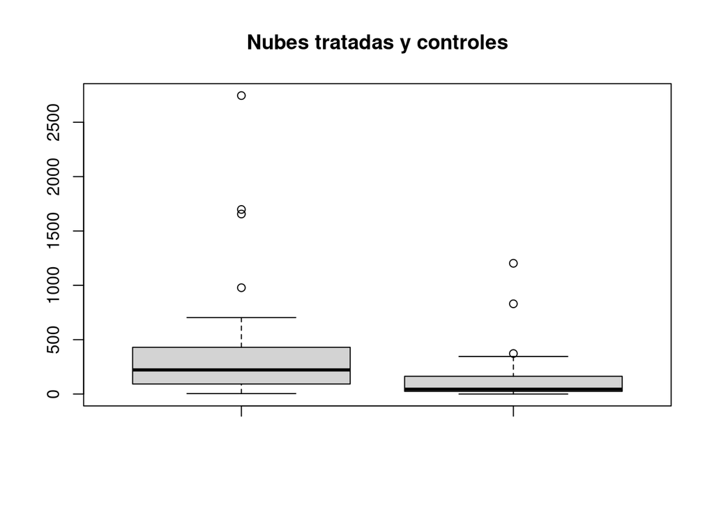

```r
tratadas = nubes$TRATADAS
controles = nubes$CONTROLES
nubs_trat_ln = log(tratadas)
nubs_contr_ln = log(controles)
boxplot(tratadas, controles, main ="Nubes tratadas y controles")
```

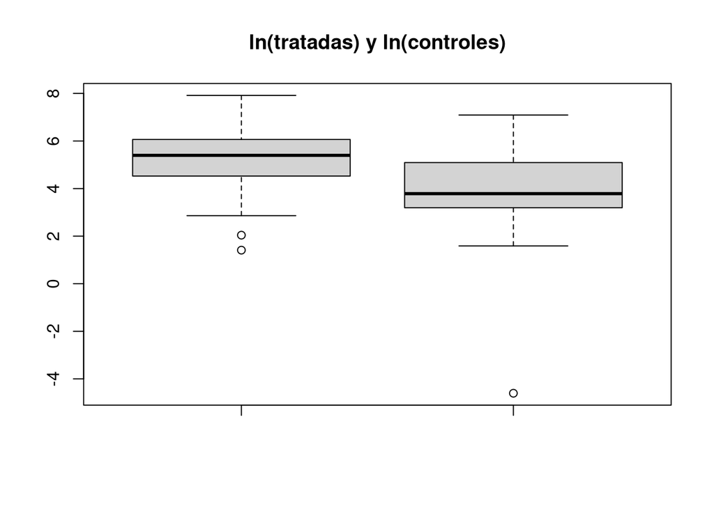

```r
boxplot(nubs_trat_ln,nubs_contr_ln, main = "ln(tratadas) y ln(controles)")
```

* Analizar la normalidad realizando qqplots e histogramas (de densidad) para ambos conjuntos de datos y superponiendo la curva normal > Concluyo que ambas distribuciones no parecen venir de una normal.

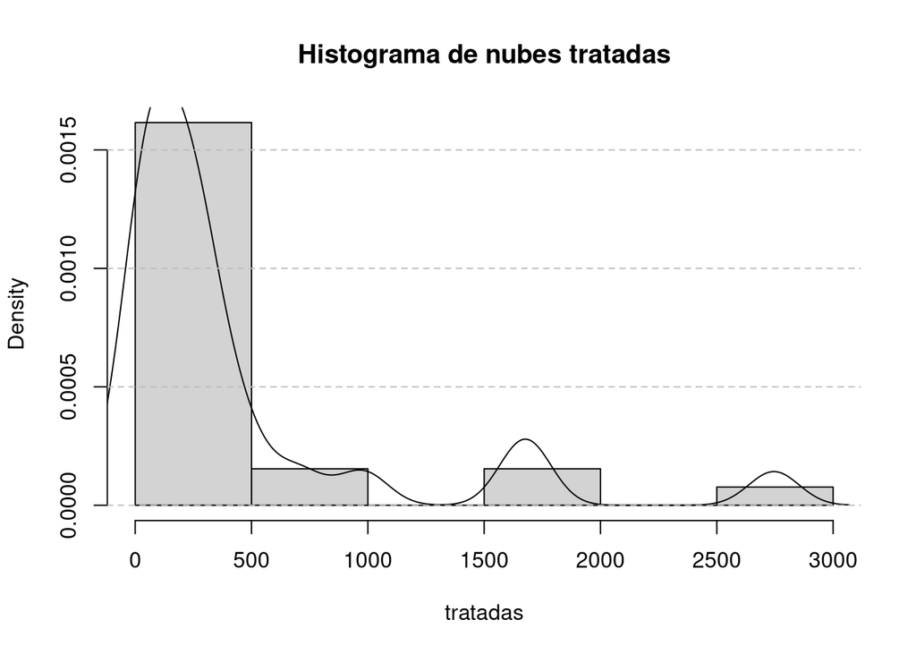

```r
hist(tratadas,freq = FALSE, main = "Histograma de nubes tratadas")
lines(density(tratadas)) # Recordar que es una aproximacion a la densidad, por el nucleo normal por defecto (creo)
grid(nx = NA, ny = NULL, lty = 2, col = "gray", lwd = 1)
```

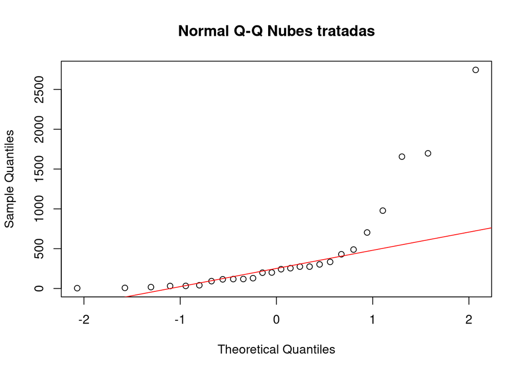

```r
qqnorm(tratadas,main="Normal Q-Q Nubes tratadas")
qqline(tratadas,col = "red")
```

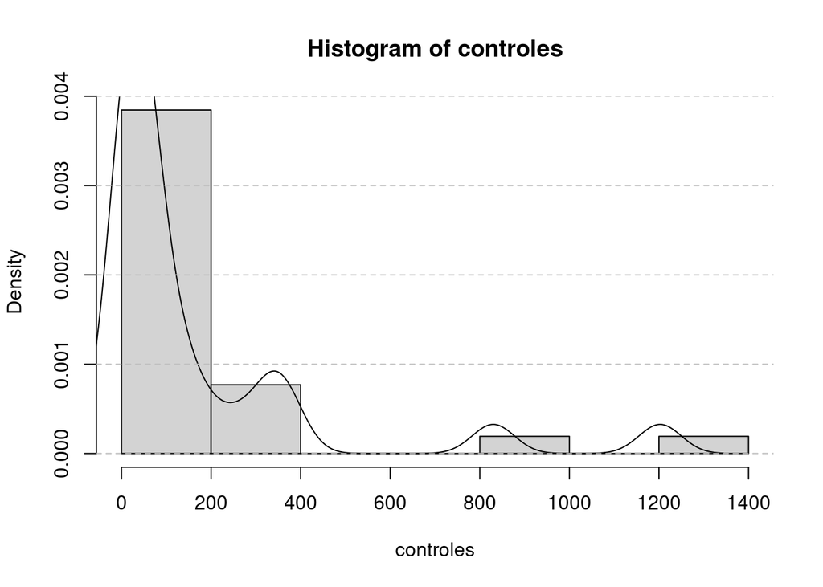

```r
hist(controles,freq = FALSE)
lines(density(controles)) # Recordar que es una aproximacion a la densidad, por el nucleo normal por defecto (creo)
grid(nx = NA, ny = NULL, lty = 2, col = "gray", lwd = 1)
```

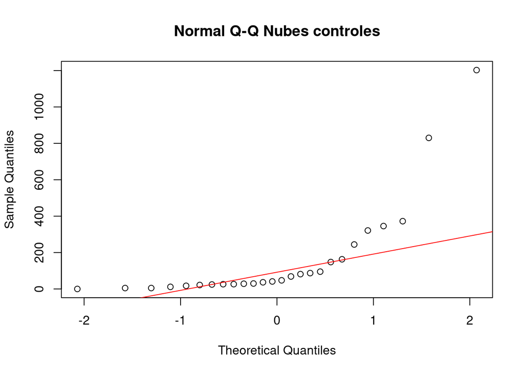

```r
qqnorm(controles,main="Normal Q-Q Nubes controles")
qqline(controles,col = "red")
```

- Realizar la transformación logaritmo natural a los datos (log en R) y repetir b) para los datos transformados. > Para las controles si no fuese por un dato atipico puede asemejarse a una normal.

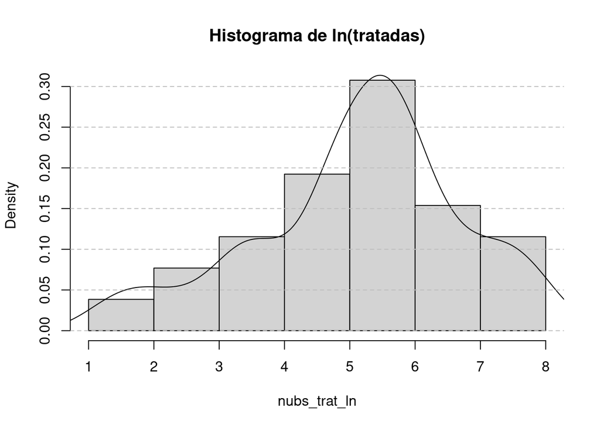

```r
#Analizamos normalidad de los datos

hist(nubs_trat_ln,freq = FALSE, main = "Histograma de ln(tratadas)")
lines(density(nubs_trat_ln)) # Recordar que es una aproximacion a la densidad, por el nucleo normal por defecto (creo)
grid(nx = NA, ny = NULL, lty = 2, col = "gray", lwd = 1)
```

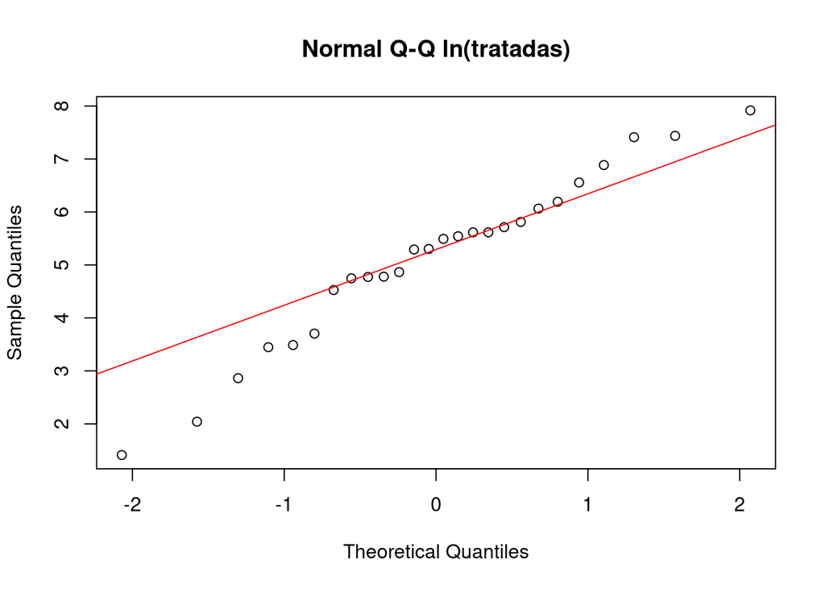

```r
qqnorm(nubs_trat_ln,main="Normal Q-Q ln(tratadas)")
qqline(nubs_trat_ln,col = "red")
```

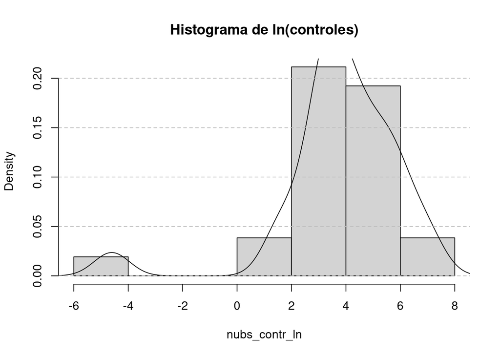

```r
hist(nubs_contr_ln,freq = FALSE, main = "Histograma de ln(controles)")
lines(density(nubs_contr_ln)) # Recordar que es una aproximacion a la densidad, por el nucleo normal por defecto (creo)
grid(nx = NA, ny = NULL, lty = 2, col = "gray", lwd = 1)
```

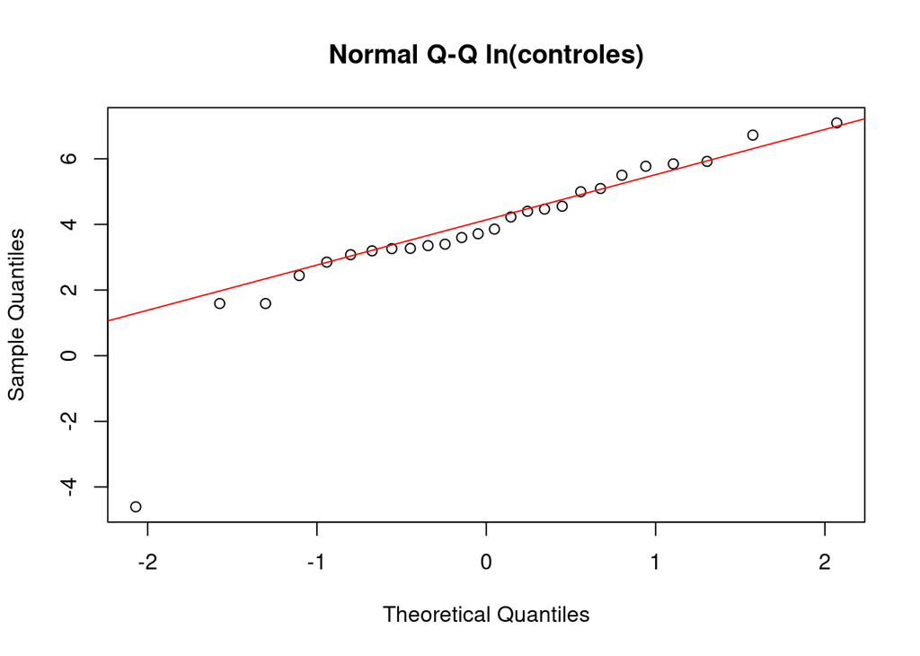

```r
qqnorm(nubs_contr_ln,main="Normal Q-Q ln(controles)")
qqline(nubs_contr_ln,col = "red")
```

# EJericio 7:

```r
setwd("~/Documents/FCEyN/Estadistica/Datos")
cpu = read.table("cpu.txt",header = TRUE)
cpu = cpu$X1.86
```

- Calcular la media muestral, la mediana muestral y la media α-podada muestral con α = 0,10 (10 %)

```r
m = matrix(ncol = 3,nrow = 1)
m[1,1] = mean(cpu)
m[1,2] = median(cpu)
m[1,3] = mean(cpu, trim = 0.1)
m = as.table(m)
rownames(m) = c("cpu")
colnames(m) = c("media","mediana","media 0.1")
m
```

```
##        media  mediana media 0.1
## cpu 4.751491 3.190000  3.929476
```

- Calcular el desvı́o estándar, la distancia intercuartil y la MAD muestrales

```r
u = matrix(nrow = 1, ncol = 3)
u[1,1] = sd(cpu)
u[1,2] = IQR(cpu)
u[1,3] = mad(cpu)
u = as.table(u)
rownames(u) = "cpu"
colnames(u) = c("desvio estandar","distancia intercuantil","MAD")
u
```

```
##     desvio estandar distancia intercuantil      MAD
## cpu        4.645589               4.475000 2.713158
```

- Realizar un histograma, un gráfico de la densidad estimada usando la función density y un boxplot. ¿Cuáles son las caracterı́sticas más sobresalientes? ¿Se observan datos atı́picos? > Se observan bastantes datos atipicos y la densidad esta corrida a izquierda.

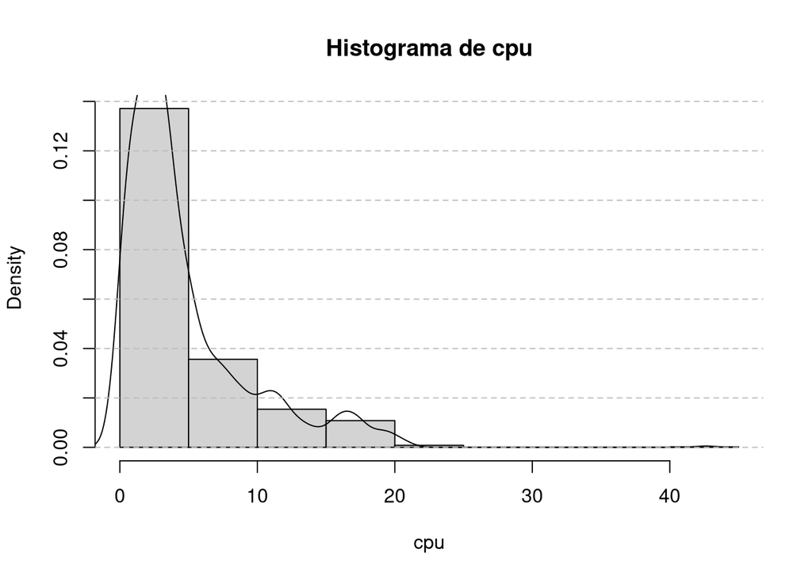

```r
hist(cpu, freq = FALSE, main = "Histograma de cpu")
lines(density(cpu))
grid(nx = NA, ny = NULL, lty = 2, col = "gray", lwd = 1)
```

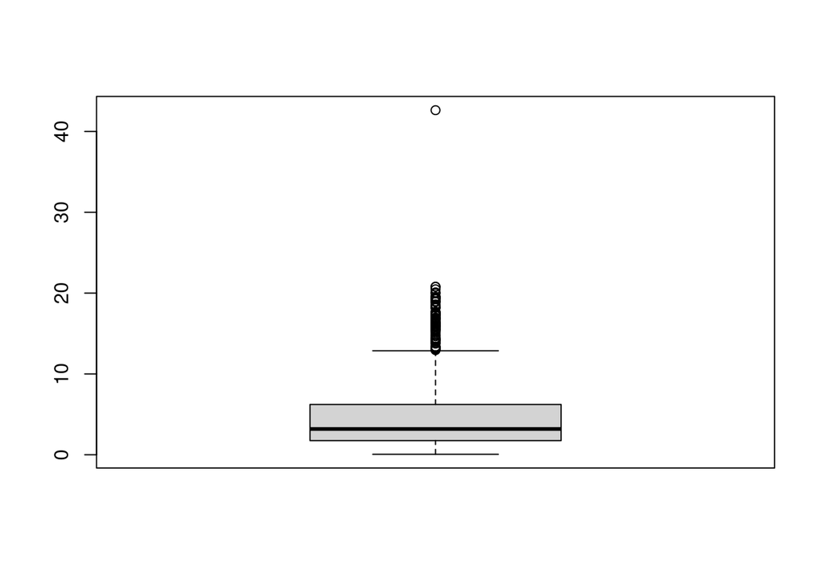

```r
boxplot(cpu)
```

- ¿Cree que los datos tienen distribución normal? Hacer un qqplot para constatar su conjetura o ponerla en duda. > No parece tener una distribucion normal.

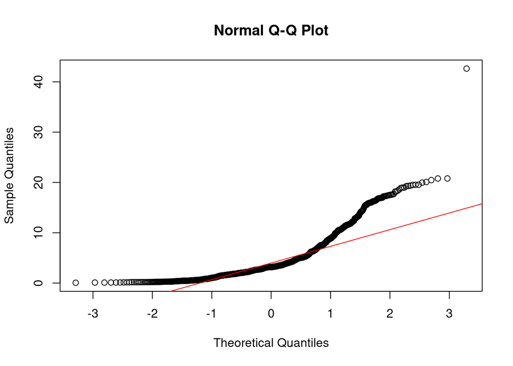

```r
qqnorm(cpu)
qqline(cpu, col = "red")
```

- ¿Qué medida de posición considera más apropiada para describir el centro de los datos?

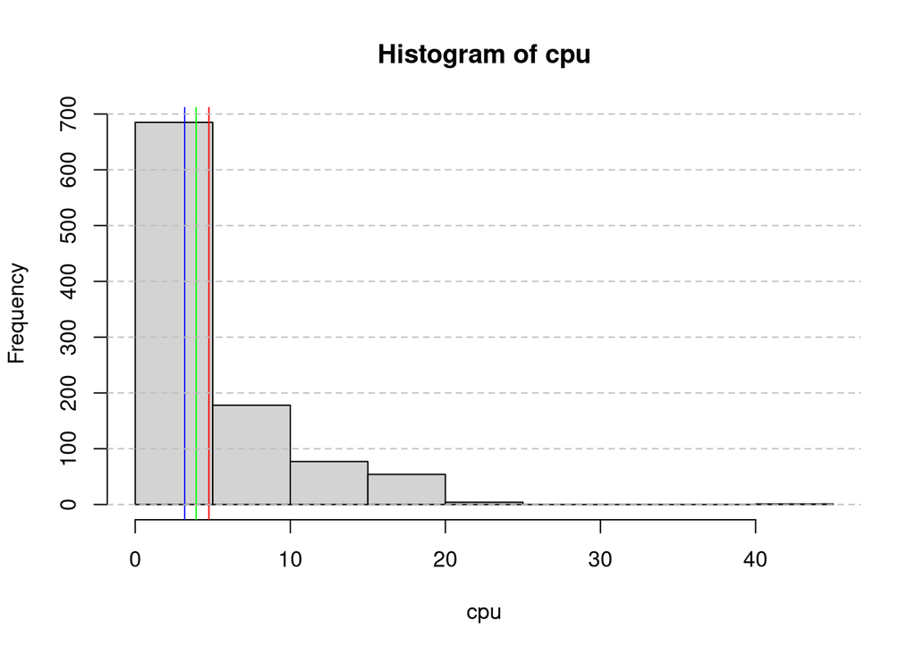

```r
hist(cpu)
abline(v = c(mean(cpu), median(cpu), mean(cpu, trim = 0.1)), col = c("red", "blue", "green"))
grid(nx = NA, ny = NULL, lty = 2, col = "gray", lwd = 1)
```

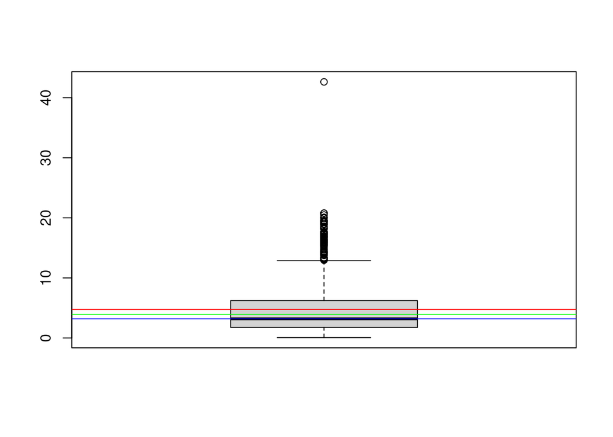

```r
boxplot(cpu)
abline(h = c(mean(cpu), median(cpu), mean(cpu, trim = 0.1)), col = c("red", "blue", "green"))
```

# Ejericio 8:

```r
setwd("~/Documents/FCEyN/Estadistica/Datos")
islander_data = read.csv("Islander_data.csv")
```

Realizar un histograma con las realizaciones de la variable aleatoria Diff, la diferencia de tiempos.

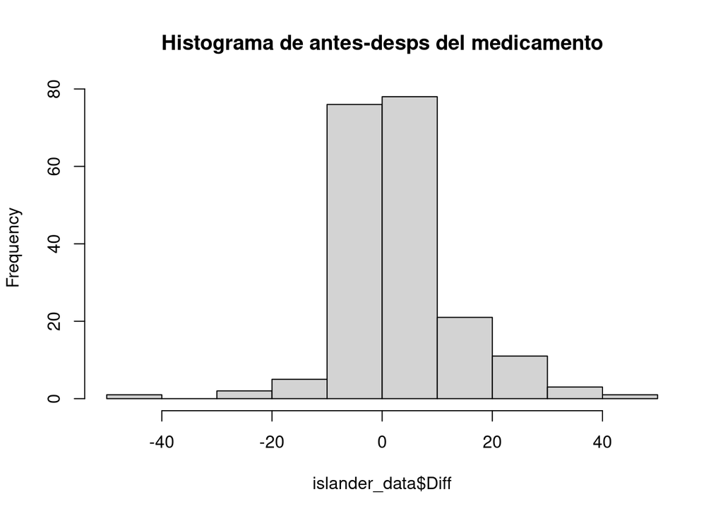

```r
hist(islander_data$Diff, main = "Histograma de antes-desps del medicamento")
```

- Estimar P(Diff ≤ 1).

```r
dif = islander_data$Diff
proba = 0
for (d in dif) {
  if(d <= 1) proba = proba + 1
}
proba = proba / length(dif)
proba
```

```
## [1] 0.4747475
```

- Graficar la función de distribución empı́rica de la variable Diff.

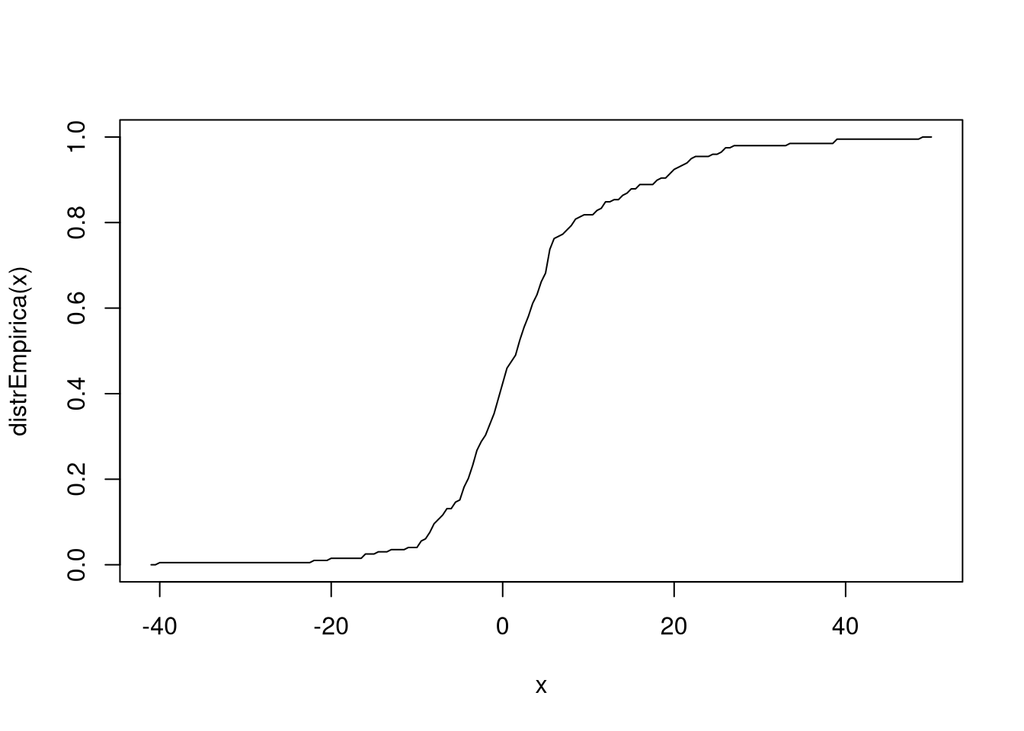

```r
distrEmpirica = function(V){
  return = 1:length(V)
  for (i in 1:length(V)) {
    res = 0
    for (d in dif) {
      if(d <= V[i]) res = res + 1
    }
    return[i] = res / length(dif)
  }
  return(return)
}
x = seq(-41,50,0.5)
plot(x,distrEmpirica(x),,xlim = c(-41,50),type="l")
```

- Estimar la densidad de Diff usando estimadores basados en núcleos, utilizando diferentes ventanas (h = 0,5, 1,5 y 2,5) y núcleos (rectangular, gaussiano y de Epanechnikov). ¿Qué observa?

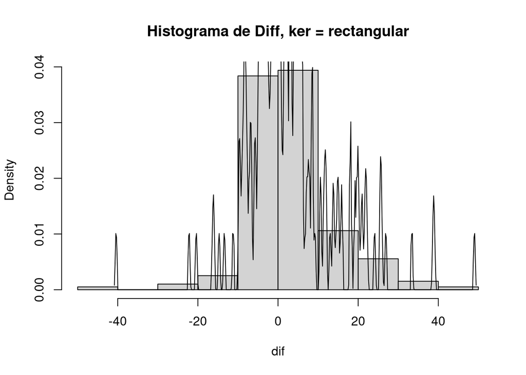

```r
hist(dif, freq = FALSE, main = "Histograma de Diff, ker = rectangular")
lines(density(dif, kernel = "rectangular", width = 0.5))
```

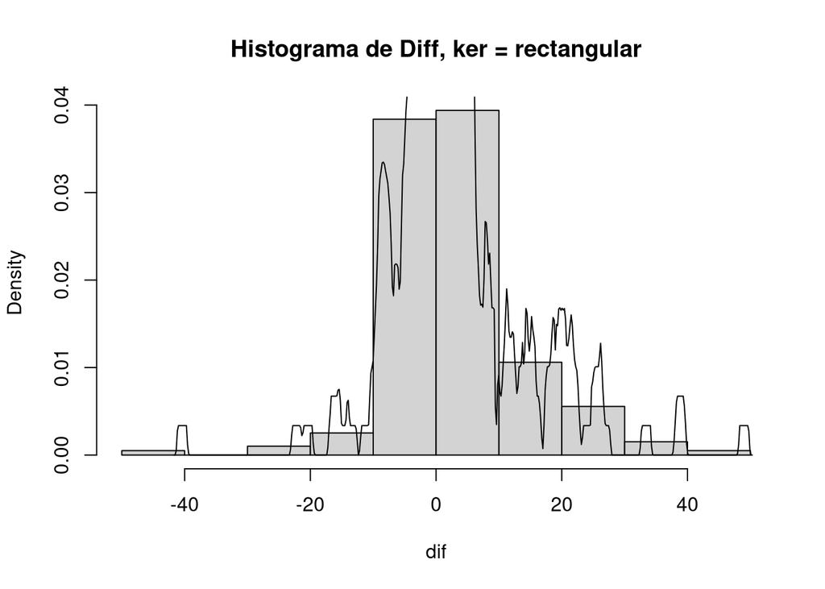

```r
hist(dif, freq = FALSE, main = "Histograma de Diff, ker = rectangular")
lines(density(dif, kernel = "rectangular", width = 1.5))
```

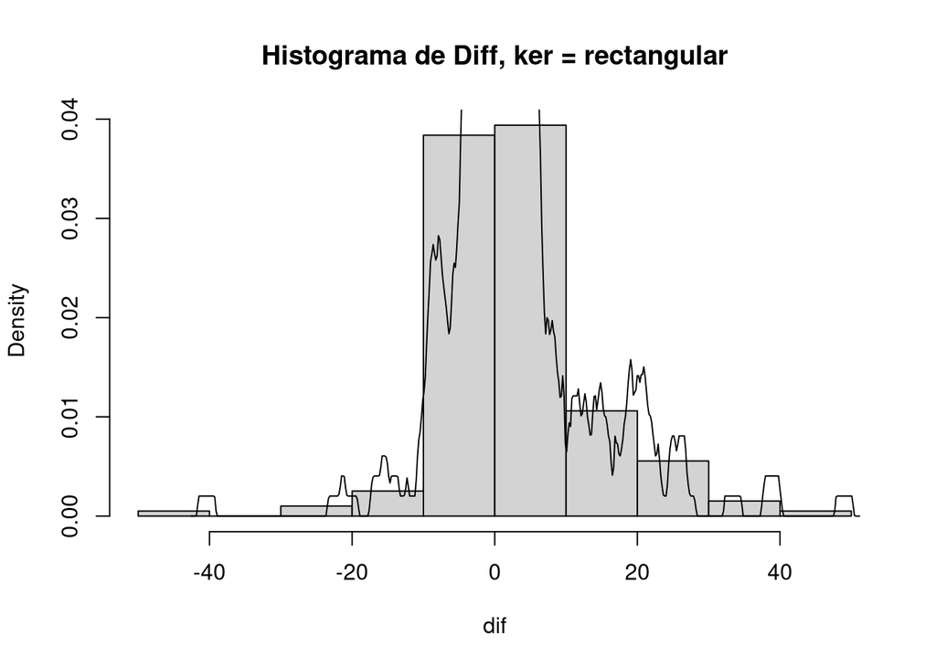

```r
hist(dif, freq = FALSE, main = "Histograma de Diff, ker = rectangular")
lines(density(dif, kernel = "rectangular", width = 2.5))
```

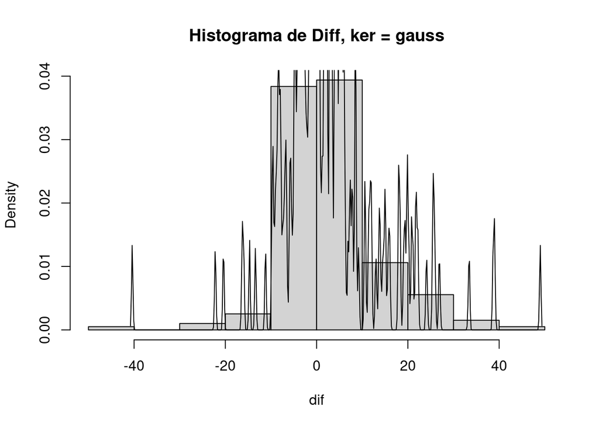

```r
hist(dif, freq = FALSE, main = "Histograma de Diff, ker = gauss")
lines(density(dif, kernel = "gaussian", width = 0.5))
```

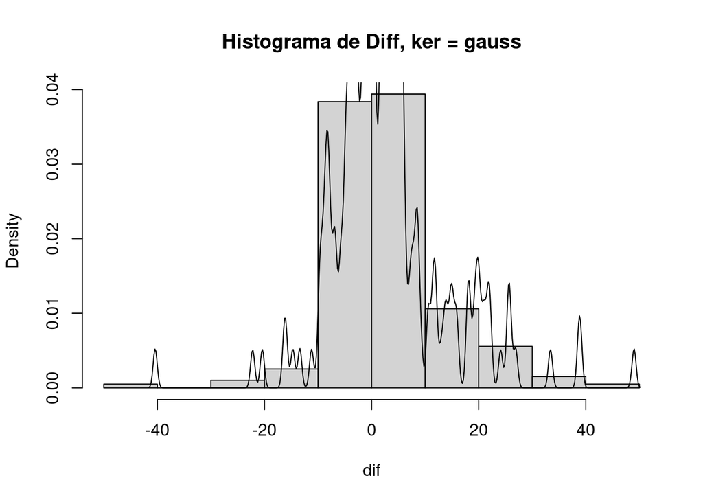

```r
hist(dif, freq = FALSE, main = "Histograma de Diff, ker = gauss")
lines(density(dif, kernel = "gaussian", width = 1.5))
```

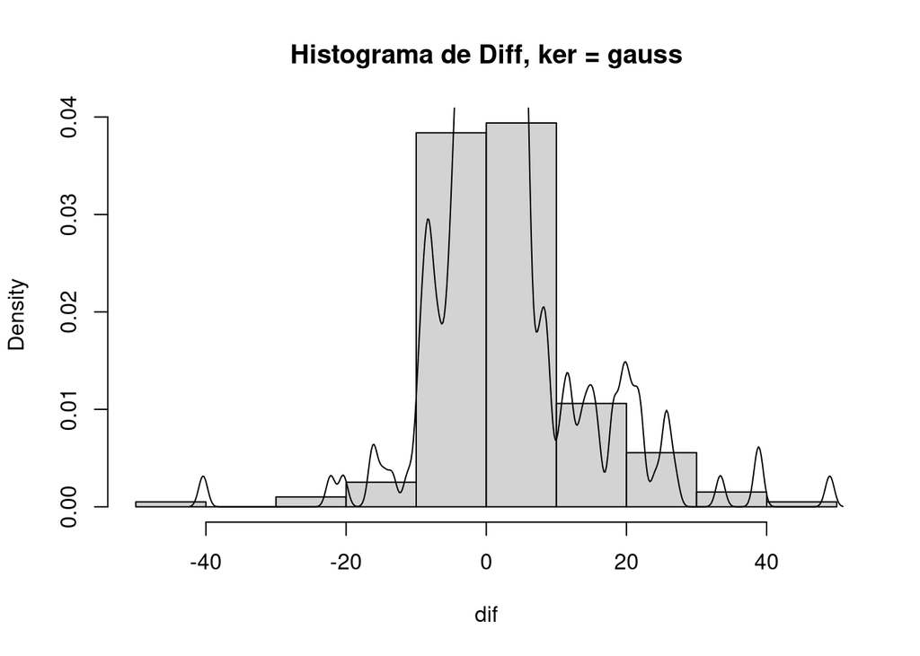

```r
hist(dif, freq = FALSE, main = "Histograma de Diff, ker = gauss")
lines(density(dif, kernel = "gaussian", width = 2.5))
```

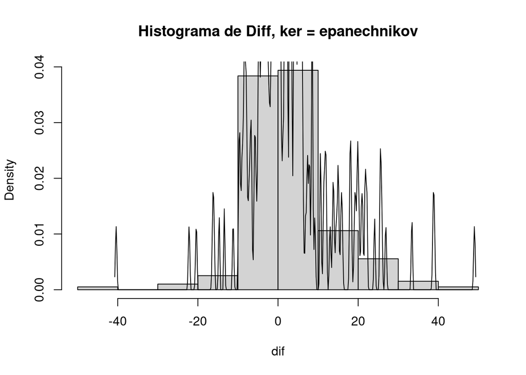

```r
hist(dif, freq = FALSE, main = "Histograma de Diff, ker = epanechnikov")
lines(density(dif, kernel = "epanechnikov", width = 0.5))
```

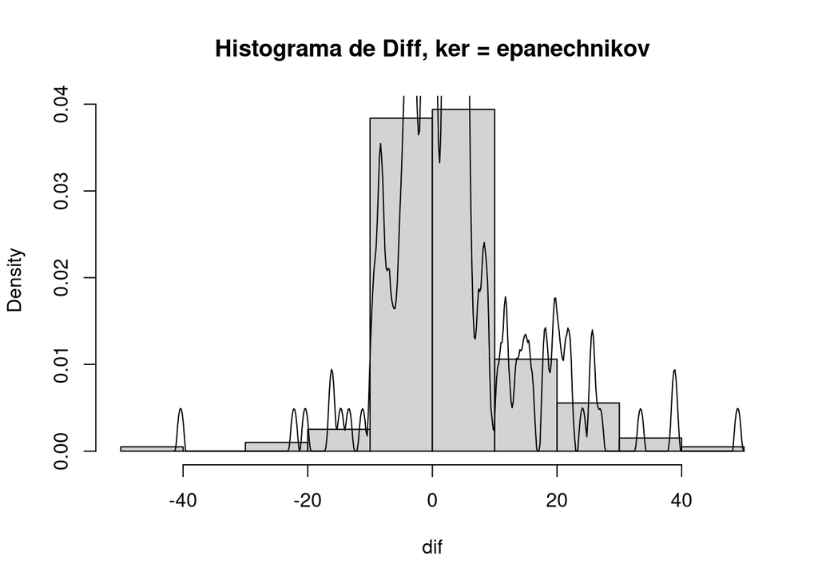

```r
hist(dif, freq = FALSE, main = "Histograma de Diff, ker = epanechnikov")
lines(density(dif, kernel = "epanechnikov", width = 1.5))
```

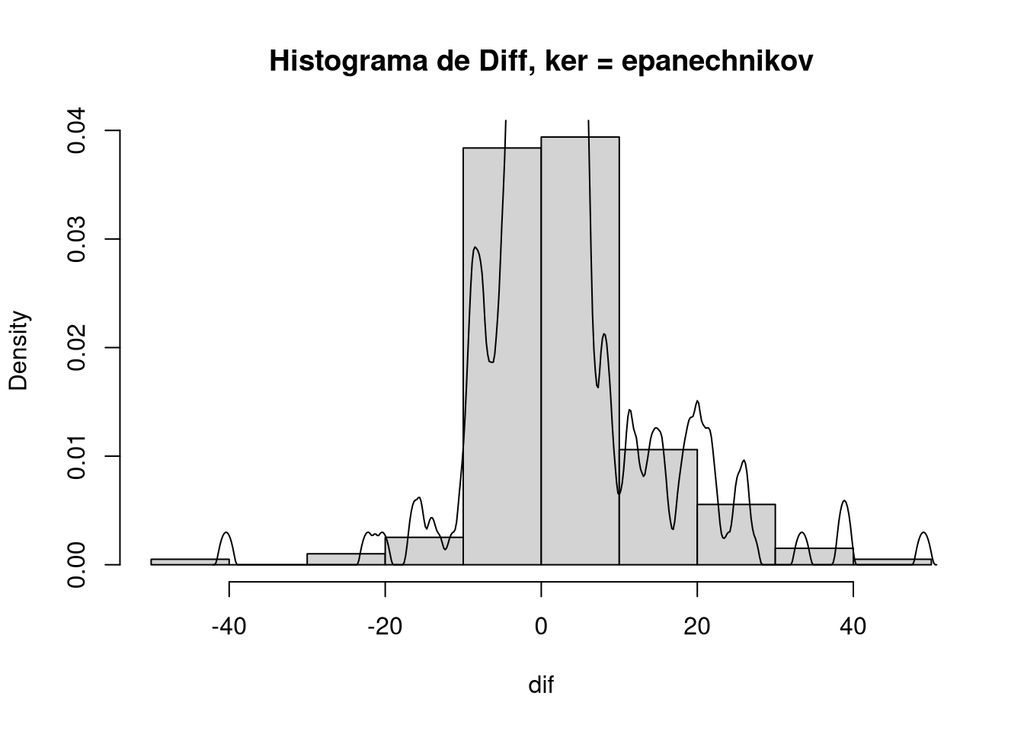

```r
hist(dif, freq = FALSE, main = "Histograma de Diff, ker = epanechnikov")
lines(density(dif, kernel = "epanechnikov", width = 2.5))
```

# Ejericio 9: (con los datos de Debernardi.csv)

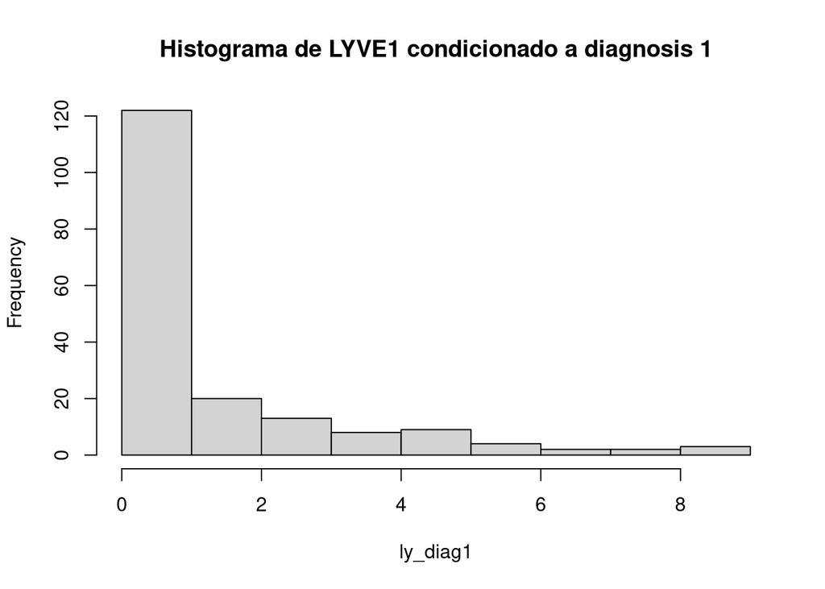

```r
ly_diag1 = debD$LYVE1[ debD$diagnosis == 1 ]
ly_diag2 = debD$LYVE1[ debD$diagnosis == 2 ]
ly_diag3 = debD$LYVE1[ debD$diagnosis == 3 ]
hist(ly_diag1, main = "Histograma de LYVE1 condicionado a diagnosis 1")
```

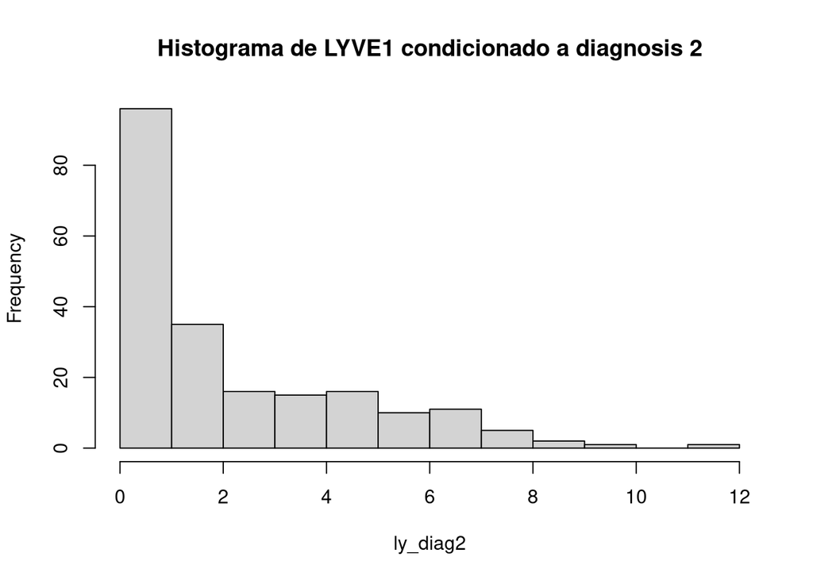

```r
hist(ly_diag2, main = "Histograma de LYVE1 condicionado a diagnosis 2")
```

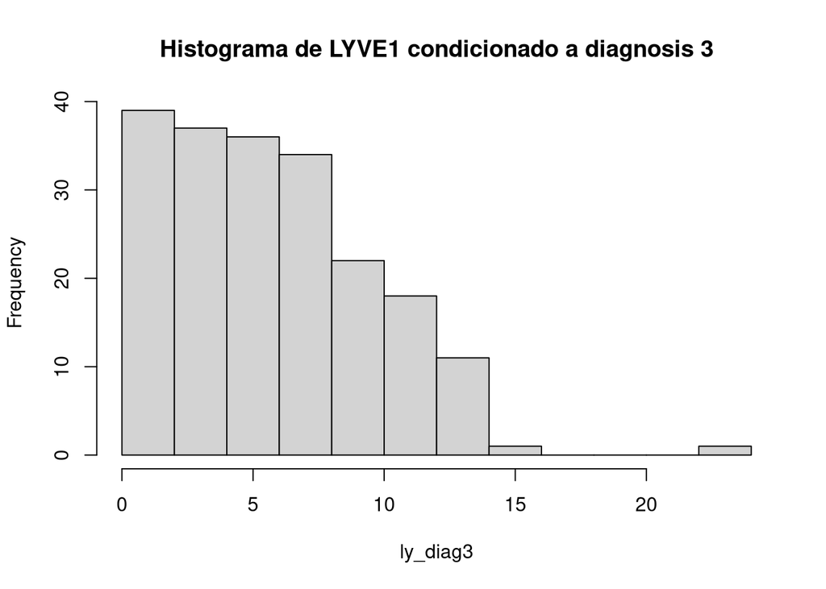

```r
hist(ly_diag3, main = "Histograma de LYVE1 condicionado a diagnosis 3")
```

- Graficar, en distintos colores y superpuestas, las funciones de distribución empı́ricas de la variable LYVE1 según los niveles de la variable factor diagnosis. Decidir si la siguiente afirmación es verdadera o falsa y justificar: “los valores de la variable LYVE1 tienden a ser más altos entre quienes tienen cáncer de páncreas que entre quienes sufren otras enfermedades asociadas al páncreas” > La afirmacion parece ser verdadera ya que para LY.. diagnosis == 3, tiende a crecer de forma mas rapida en los datos mas “altos”.

```r
ly_diag1
```

[output not shown]

[output cut: 16 more lines]

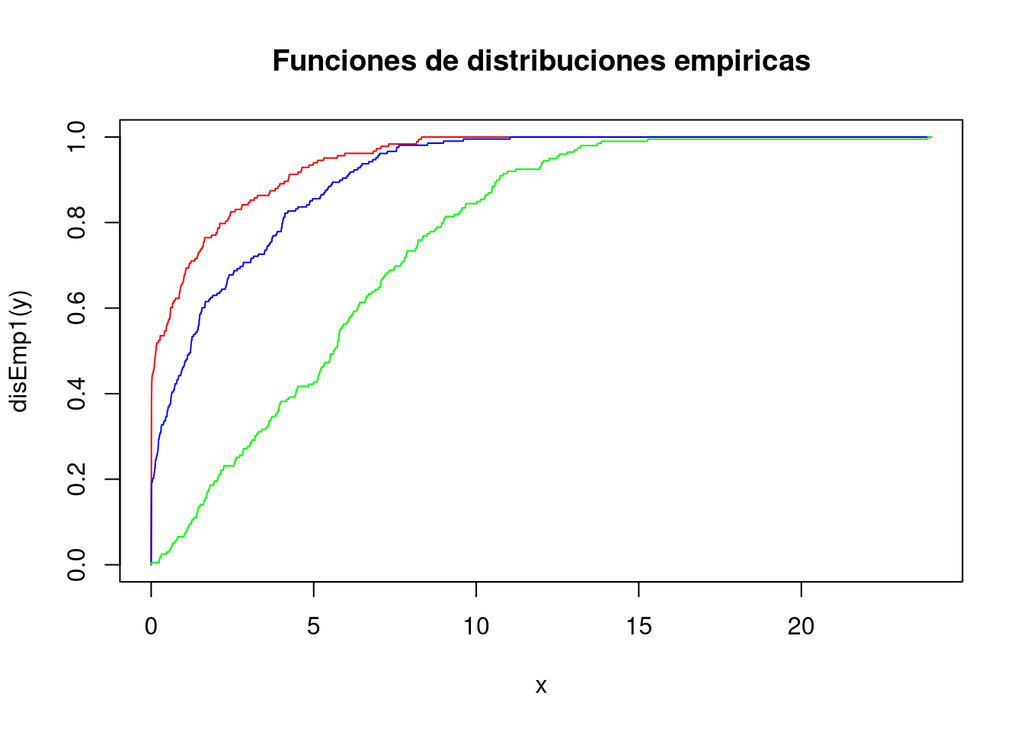

```r
disEmp1 = function(V){
  return = 1:length(V)
  for (i in 1:length(V)) {
    res = 0
    for (d in ly_diag1) {
      if(d <= V[i]) res = res + 1
    }
    return[i] = res / length(ly_diag1)
  }
  return(return)
}
disEmp2 = function(V){
  return = 1:length(V)
  for (i in 1:length(V)) {
    res = 0
    for (d in ly_diag2) {
      if(d <= V[i]) res = res + 1
    }
    return[i] = res / length(ly_diag2)
  }
  return(return)
}
disEmp3 = function(V){
  return = 1:length(V)
  for (i in 1:length(V)) {
    res = 0
    for (d in ly_diag3) {
      if(d <= V[i]) res = res + 1
    }
    return[i] = res / length(ly_diag3)
  }
  return(return)
}
y = seq(0,24,0.01)

plot(y,disEmp1(y),type = "l", col = "red", xlab = "x", main = "Funciones de distribuciones empiricas")
lines(y,disEmp2(y),col = "blue")
lines(y,disEmp3(y),col = "green")
```

- Realizar boxplots paralelos para la variable LYVE1 según los niveles de la variable factor diagnosis, considerando el sexo de los pacientes (variable sex). Decidir si la siguiente afirmación es verdadera o falsa y justificar: “en términos generales, el sexo del paciente no afecta los niveles de la proteı́na que se mide en la variable LYVE1”. > Por lo menos para valores de Ly.. condicionando a diagnosis = 1, parece tener una leve inclinacion a hombres respecto a mujeres.

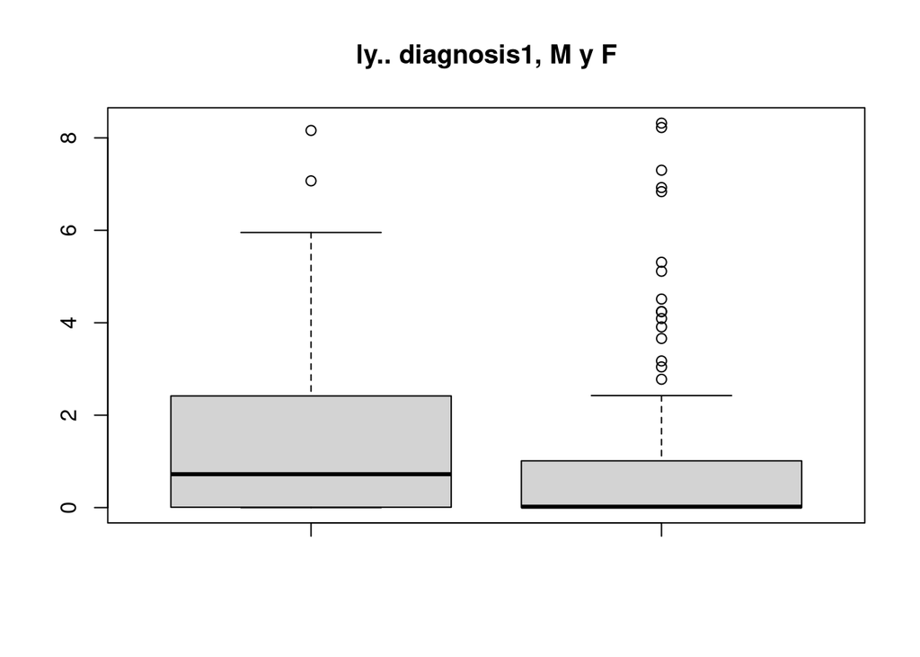

```r
ly_diag1_M = debD$LYVE1[debD$sex == "M" & debD$diagnosis == 1]
ly_diag1_F = debD$LYVE1[debD$sex == "F" & debD$diagnosis == 1]
ly_diag2_M = debD$LYVE1[debD$sex == "M" & debD$diagnosis == 2]
ly_diag2_F = debD$LYVE1[debD$sex == "F" & debD$diagnosis == 2]
ly_diag3_M = debD$LYVE1[debD$sex == "M" & debD$diagnosis == 3]
ly_diag3_F = debD$LYVE1[debD$sex == "F" & debD$diagnosis == 3]
boxplot(ly_diag1_M,ly_diag1_F, main = "ly.. diagnosis1, M y F")
```

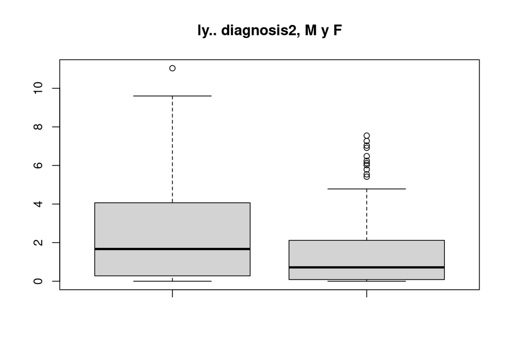

```r
boxplot(ly_diag2_M,ly_diag2_F, main = "ly.. diagnosis2, M y F")
```

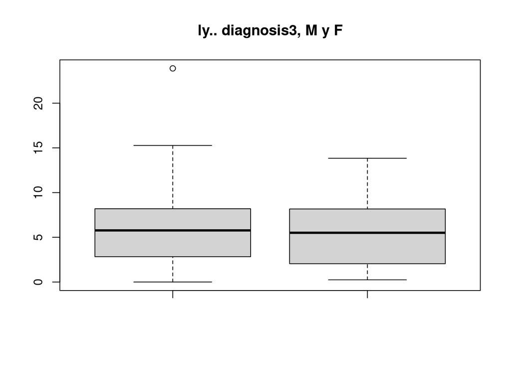

```r
boxplot(ly_diag3_M,ly_diag3_F, main = "ly.. diagnosis3, M y F")
```

- Graficar superpuestas las densidades estimadas, que brinda la función density, para la variable LYVE1 según los niveles de la variable factor diagnosis. Describir las caracterı́sticas más sobresalientes de las densidades estimadas y aquellas que las diferencian. > La caracteristica mas notoria que veo es la misma caracteristica que en la funcion de proba acumulada.

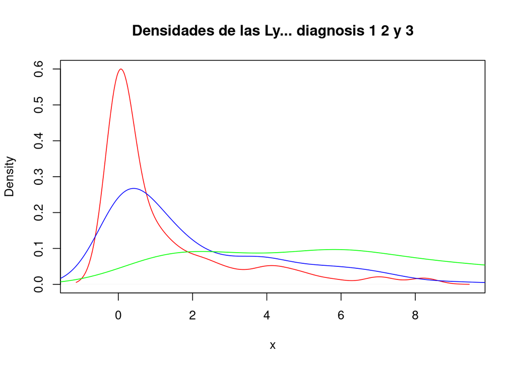

```r
plot(density(ly_diag1),col = "red", main = "Densidades de las Ly... diagnosis 1 2 y 3", xlab = "x")
lines(density(ly_diag2), col = "blue")
lines(density(ly_diag3), col = "green")
```